# Titanic - Data Analysis

Yueqi Liu

10/27/2019

# Project Description

In this project, we build predictive models for Titanic Data. From the course project, we learn that a simple logistic regression without cross validation yields an unconvincing reseult. So, we make several changes compared with the previous model.

1. Handle missing value in a different way. It is potential that the replacement of average is a good approach, we will try to use other method to deal with this problem.
2. Use cross validation to check the reliability of the model. The involvement of missing value make it different from the common approach of cross validation.
3. Try different predictive model. In this project, we try to use logistic regression and random forest to accomplish prediction tasks.

## Data Summary

The sinking of RMS Titanic is a huge tragedy, killing 1502 out of 2224 passengers and crew. One of the reasons that the shipwreck led to such loss of life was that there were not enough lifeboats for the passengers and crew. Although there was some element of luck involved in surviving the sinking, some groups of people were more likely to survive than others, such as women, children, and the upper-class.

[figure not shown]

The sinking Titanic

# 1. Package

The following libraries are included.

```r
library(dplyr)
library(ggplot2)
library(data.table)
library(stringr)
library(ROCR)
library(randomForest)
library(xgboost)
library(VIM)
library(mice)
library(MASS)
library(glmnet)
library(pdp)
library(vip)
```

# 2. Data Maipulation and Feature Engineering

Load training dataset and convert all character variables into factors.

```r
originData <- fread("~/Desktop/train.csv")
Training <- originData %>%
  mutate_if(sapply(originData,is.character), as.factor) %>%
  mutate(Name = as.character(Name))
```

Convert integer variable into factors, convert empty values into NA, created two new variables: cabinGrp and title of each passenger based on original variables: cabin and name and deleted unuseful variables: Ticket and Cabin.

Specifically, we created variable Title by extracting the title information of passengers from their names in order to better explore whether passengers with different titles will have different survival probabilities.

Check and impute missing values of both continuous and categorical variables using mice() function. The first plot shows that there are missing values in variable Age and Embarked, after the imputation, the second plot shows that, in the imputed data, there is no missing value in any of the variables.

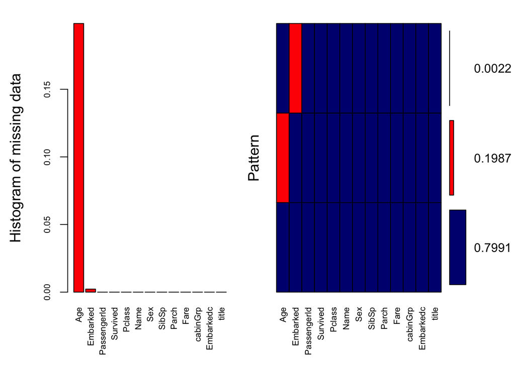

```
##
##  Variables sorted by number of missings:
##     Variable       Count
##          Age 0.198653199
##     Embarked 0.002244669
##  PassengerId 0.000000000
##     Survived 0.000000000
##       Pclass 0.000000000
##         Name 0.000000000
##          Sex 0.000000000
##        SibSp 0.000000000
##        Parch 0.000000000
##         Fare 0.000000000
##     cabinGrp 0.000000000
##    Embarkedc 0.000000000
##        title 0.000000000
```

```r
aggr_plot <- aggr(Training,
                  col = c('navyblue','red'),
                  numbers = TRUE,
                  sortVars = TRUE,
                  labels = names(Training),
                  cex.axis = .7,
                  gap = 3,
                  ylab = c("Histogram of missing data","Pattern"))
```

```r
imputed_Data1 <- mice(data = Training,
                     m = 5,
                     meth = 'pmm',
                     maxit = 50,
                     seed = 500,
                     printFlag = FALSE)
```

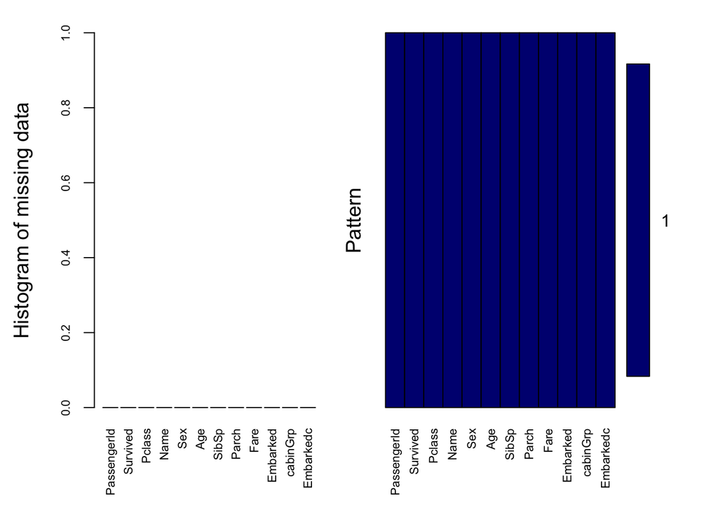

```
##
##  Variables sorted by number of missings:
##     Variable Count
##  PassengerId     0
##     Survived     0
##       Pclass     0
##         Name     0
##          Sex     0
##          Age     0
##        SibSp     0
##        Parch     0
##         Fare     0
##     Embarked     0
##     cabinGrp     0
##    Embarkedc     0
```

Then, we move on to check the relationship between the Survive reponse and some variables straightforwardly with histograms. Firstly, from the histogram of Age versus Survived, we find that survived rates of passengers with the age under 18 or above 75 are higher than other passengers.

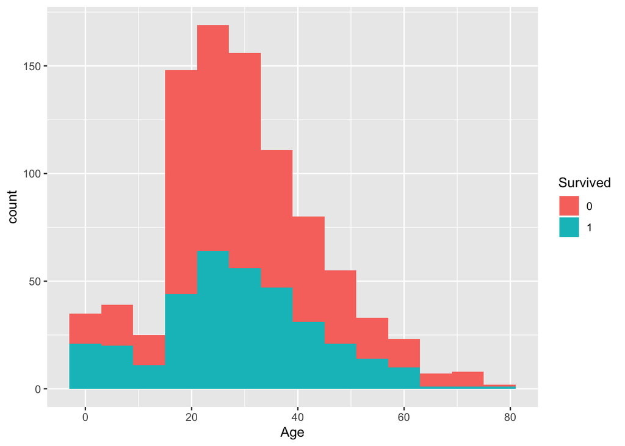

From the histogram of Fare vesus Survived, we find that passengers who paid higher fare have higher survival rates.

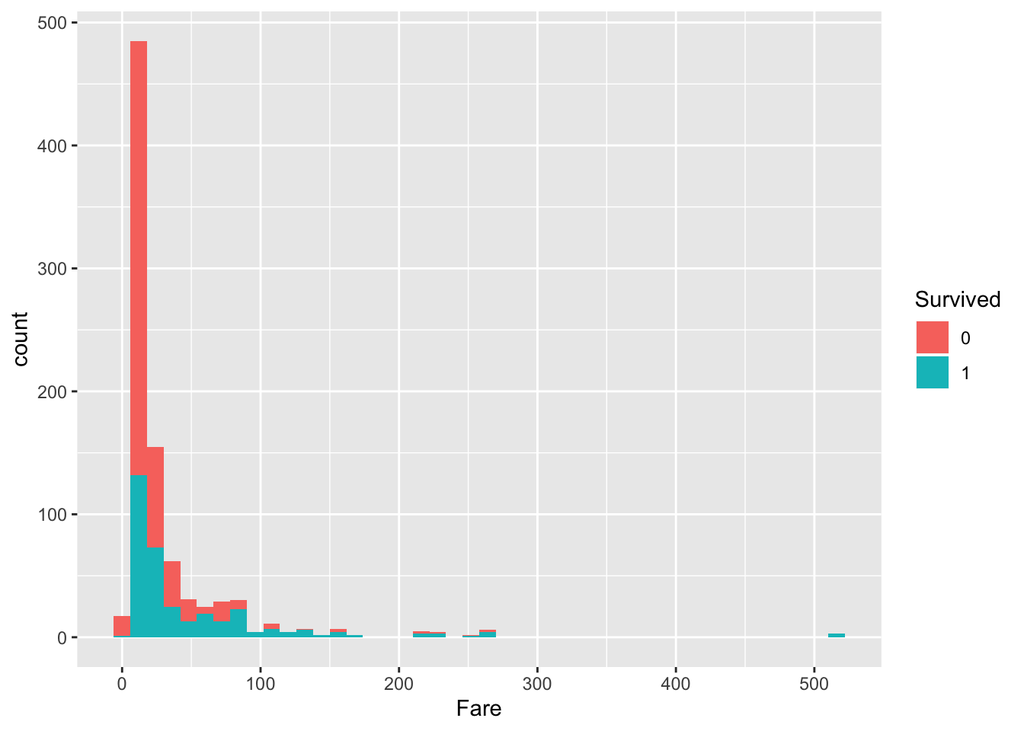

Similarly to Fare variable, the histogram of Pclass (Ticket Class) versus Survived shows that passengers with higher level tickets have higher survival rates than those with lower level tickets.

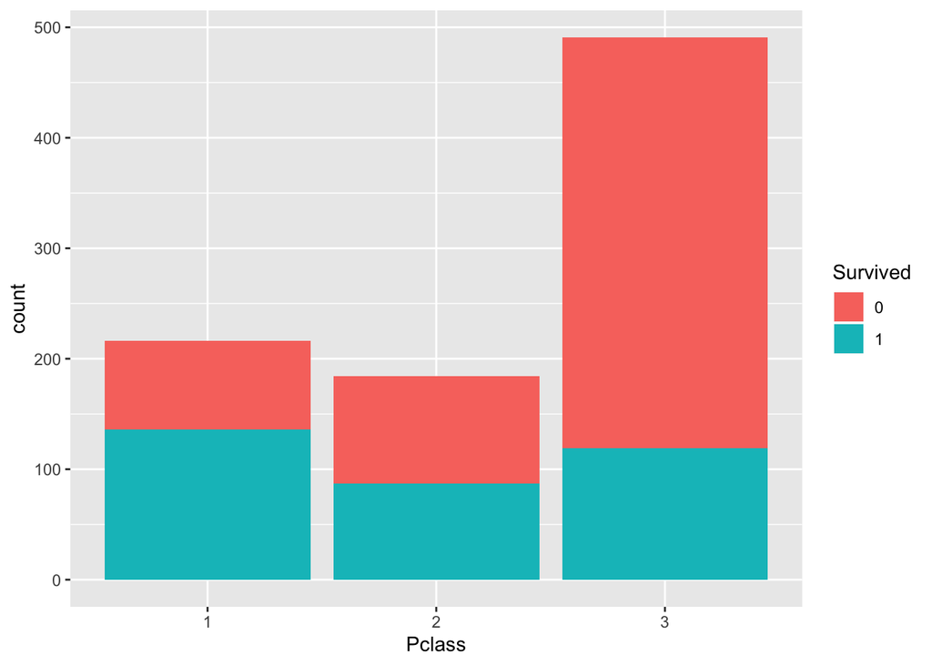

The following histogram of Sex versus Survived shows obvious trend that females have higher survival rates than males.

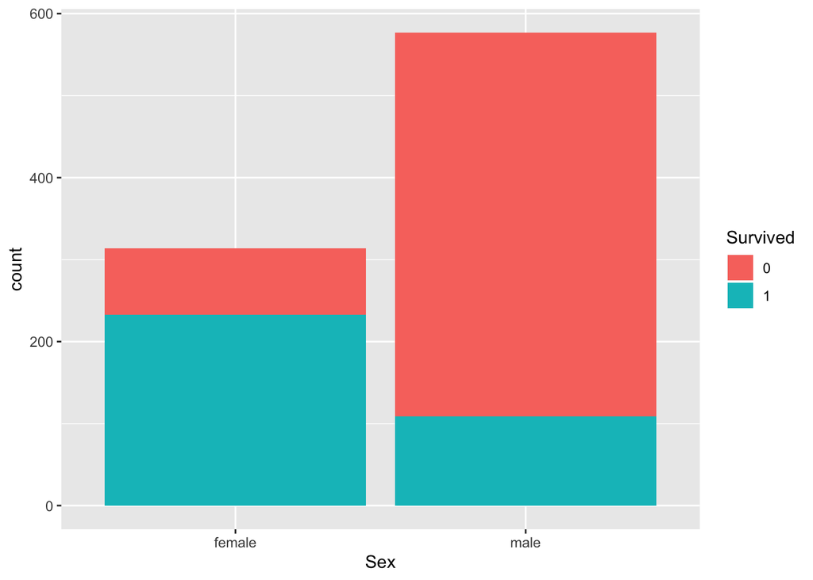

From the histogram of Embarked versus Survived, we can tell a little difference of survival rates between different levels of Embarked, but the difference is not obvious. We can keep this variable to explore further later.

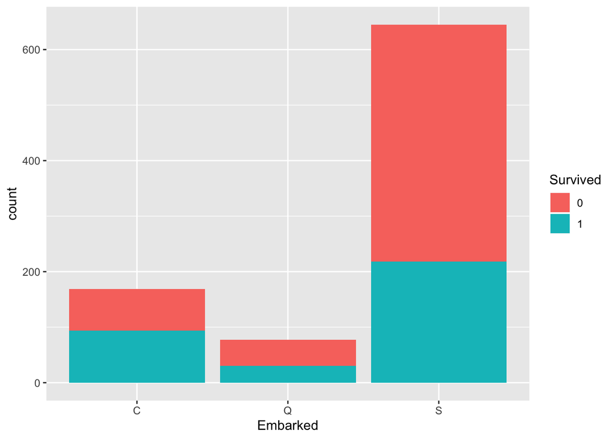

Because the information of Cabin Group is incomplete, we still need to explore further about this variable later.

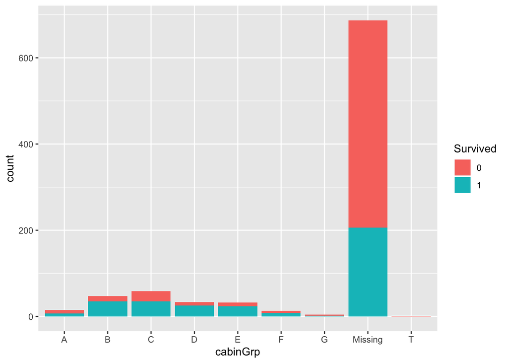

The histogram of Title versus Survived obviously shows that survival rates of passengers varies with their titles.

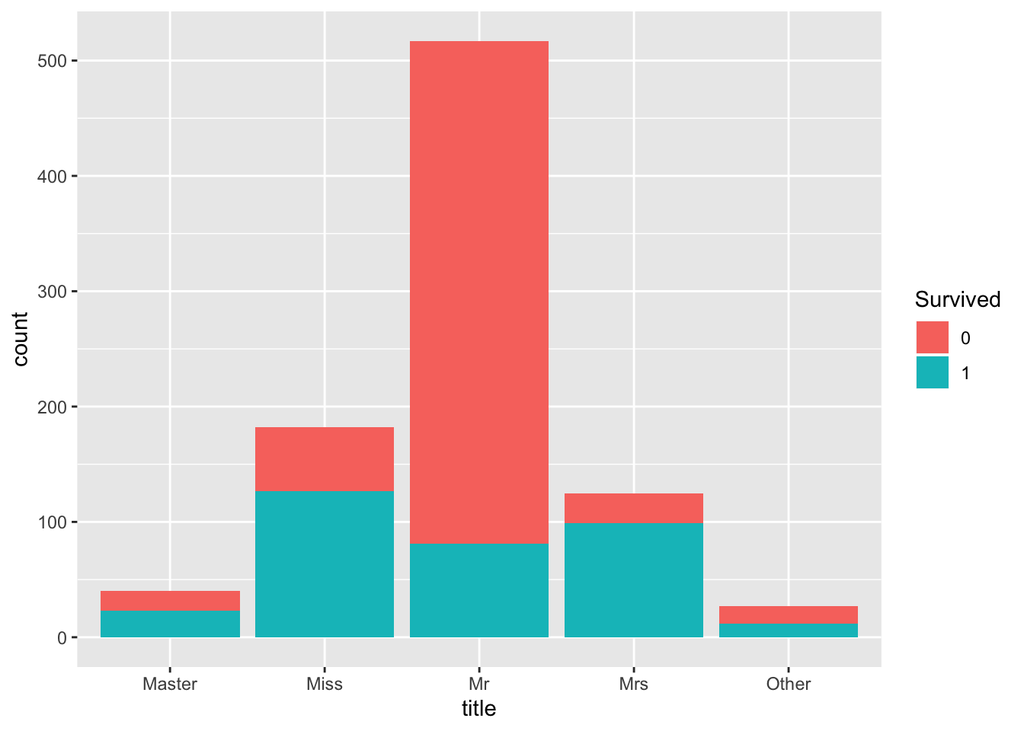

# 3. First Model: Logistic Regression

We firstly try to the most common model: logistic regression.

```
##
## Call:
## glm(formula = Survived ~ ., family = binomial, data = trainingSet %>%
##     dplyr::select(-PassengerId, -Name))
##
## Deviance Residuals:
##     Min       1Q   Median       3Q      Max
## -2.3733  -0.5816  -0.4103   0.5334   2.3902
##
## Coefficients:
##                   Estimate Std. Error z value Pr(>|z|)
## (Intercept)      19.135856 629.011068   0.030 0.975730
## Pclass2          -0.541508   0.557465  -0.971 0.331361
## Pclass3          -1.543658   0.566326  -2.726 0.006416 **
## Sexmale         -16.020430 629.010519  -0.025 0.979681
## Age              -0.020891   0.010614  -1.968 0.049034 *
## SibSp            -0.507820   0.152686  -3.326 0.000881 ***
## Parch            -0.384307   0.154631  -2.485 0.012944 *
## Fare              0.005490   0.003508   1.565 0.117593
## EmbarkedQ         0.150033   0.507290   0.296 0.767418
## EmbarkedS        -0.333780   0.312016  -1.070 0.284730
## cabinGrpB         0.309695   0.841779   0.368 0.712944
## cabinGrpC        -0.228030   0.827728  -0.275 0.782941
## cabinGrpD         1.438663   0.898841   1.601 0.109471
## cabinGrpE         1.189099   0.896370   1.327 0.184650
## cabinGrpF         0.360635   1.370230   0.263 0.792402
## cabinGrpG        -0.527505   1.665376  -0.317 0.751435
## cabinGrpMissing   0.045567   0.819869   0.056 0.955677
## titleMiss       -16.352933 629.010869  -0.026 0.979259
## titleMr          -3.049990   0.689421  -4.424 9.69e-06 ***
## titleMrs        -15.561910 629.010951  -0.025 0.980262
## titleOther       -2.835753   0.936069  -3.029 0.002450 **
## ---
## Signif. codes:  0 '***' 0.001 '**' 0.01 '*' 0.05 '.' 0.1 ' ' 1
##
## (Dispersion parameter for binomial family taken to be 1)
##
##     Null deviance: 797.85  on 599  degrees of freedom
## Residual deviance: 499.85  on 579  degrees of freedom
## AIC: 541.85
##
## Number of Fisher Scoring iterations: 14
```

```
## [1] 0.8448276
```

```
## [1] 0.8123303
```

# 4. Second Model: Elastic Net Regression

```
## [1] 0.7741286
```

Also from the list of coefficient estimations, we can easily find the relationship between the survival probabiliy and passengers’ information in different aspects. Coefficients for variable Parch and Fare have been shrinked to zero and reduced from the model.

Therefore, from the estimations, we find:

```
## 10 x 1 sparse Matrix of class "dgCMatrix"
##                      s0
## (Intercept)  3.85196916
## Pclass      -0.46592972
## Sex         -1.86252643
## Age          .
## SibSp        .
## Parch        .
## Fare         .
## Embarked     .
## cabinGrp    -0.03683672
## title        .
```

# 5. Third model: Random Forest

```
## [1] 0.8429319
```

```
##           MeanDecreaseAccuracy
## Pclass               41.777199
## Sex                  24.464514
## Age                  15.183612
## SibSp                13.158080
## Parch                -1.063895
## Fare                 21.244716
## Embarked              8.344097
## cabinGrp             17.144014
## title                31.753496
## foldIndex            -1.464064
```

```
##          MeanDecreaseAccuracy
## Pclass              31.617331
## Sex                 26.971600
## Age                 13.881973
## SibSp               18.587167
## Parch                1.900071
## Fare                18.546656
## Embarked             7.401749
## cabinGrp            18.703541
## title               31.428257
```

```
## [1] 0.8328464
```

With the variable importance, we tried a reduced random forest model after deleting two variables with less importantce.

```
##          MeanDecreaseAccuracy
## Pclass               44.54164
## Sex                  26.99950
## Age                  19.57489
## SibSp                17.45597
## Fare                 26.62178
## cabinGrp             19.59634
## title                34.70689
```

```
## [1] 0.8261174
```

# 6. Conclusion

The partial dependence plot shows how the average prediction in your dataset changes when the j-th feature is changed.

So, from the following plots of each feature versus the response variabe (survived or not), we find that all kept variables in this model have significant effects on the survival results.

Importantly:

1. The Pclass (ticket class) PDP shows the negative relationship between the ticket class and the average survival prediction to 1. Also, passengers in with the first class ticket are more likely to survive.
2. The title (of passengers) PDP shows that males (with ‘Mr’ as titles) are less likely to survive, females (with ‘Mrs’ or ‘Miss’) are more likely to survive, also, passengers with special titles (eg:‘master’, ‘capital’ or ‘doc’ etc.) have higher probability to be predicted as survived.
3. If a passenger paid the ticket for a too low price, his/her suvival probability would be significantly low. If passengers paid more than 50 dollars for their ticket, the survival result won’t be different significantly.
4. Young passengers who are under 18 years old are more likely to survive.
5. Corresponding to the analysis in (2), Sex PDP shows that females have much more probabilities to survive than males.
6. SibSp PDP shows that passengers with more than 4 families on board have much lower probabilities to survive.

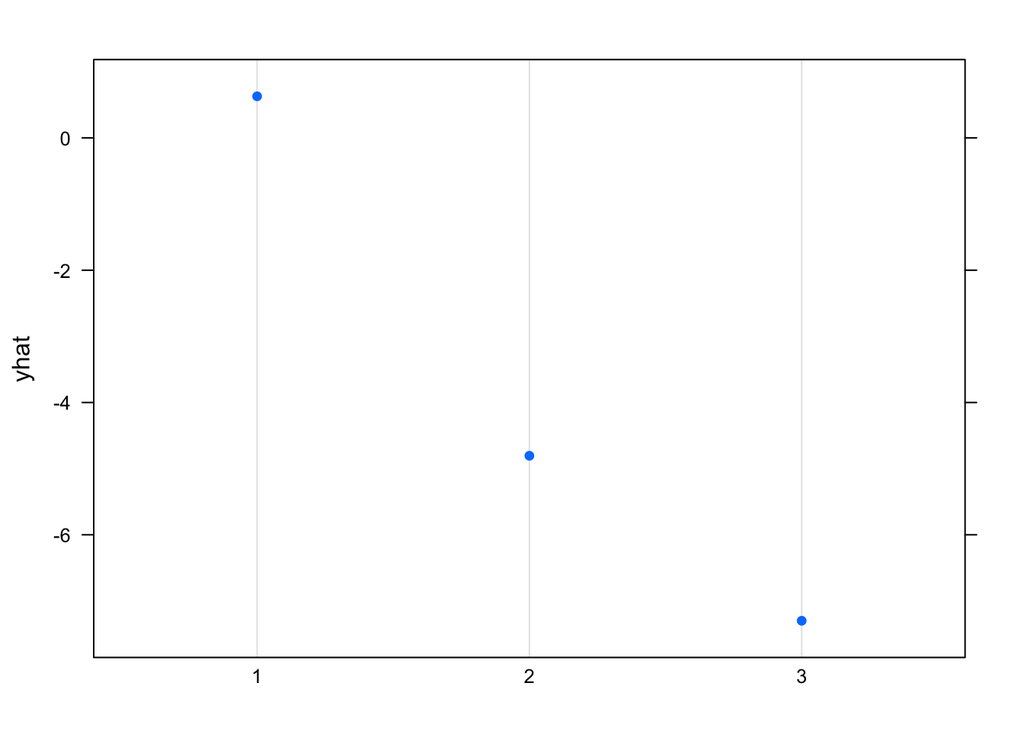

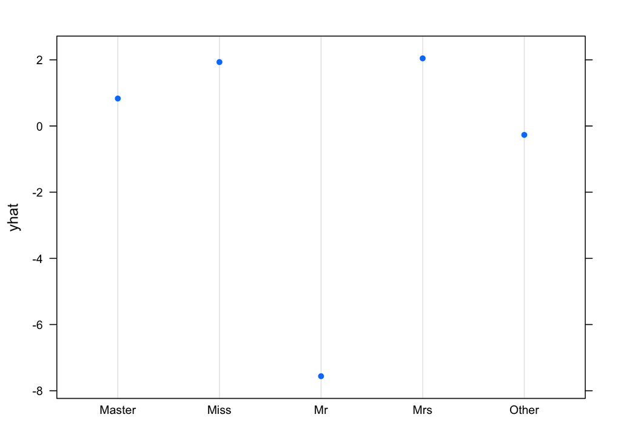

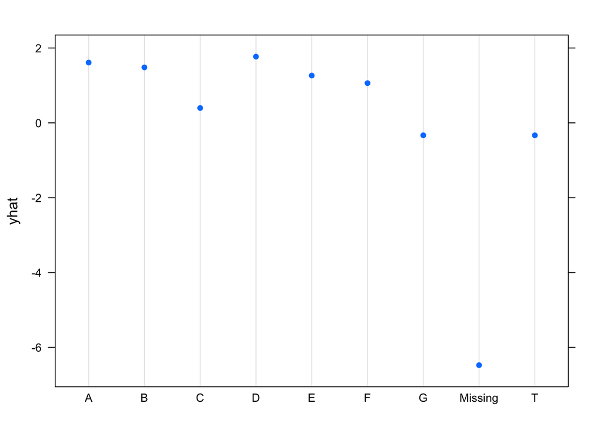

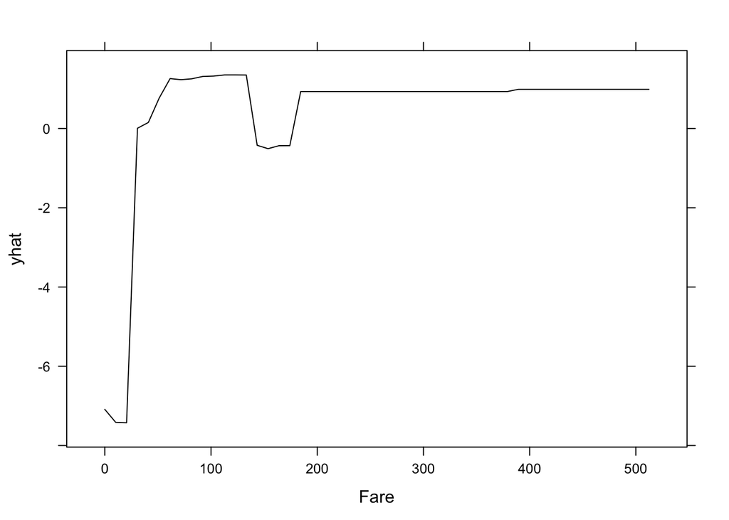

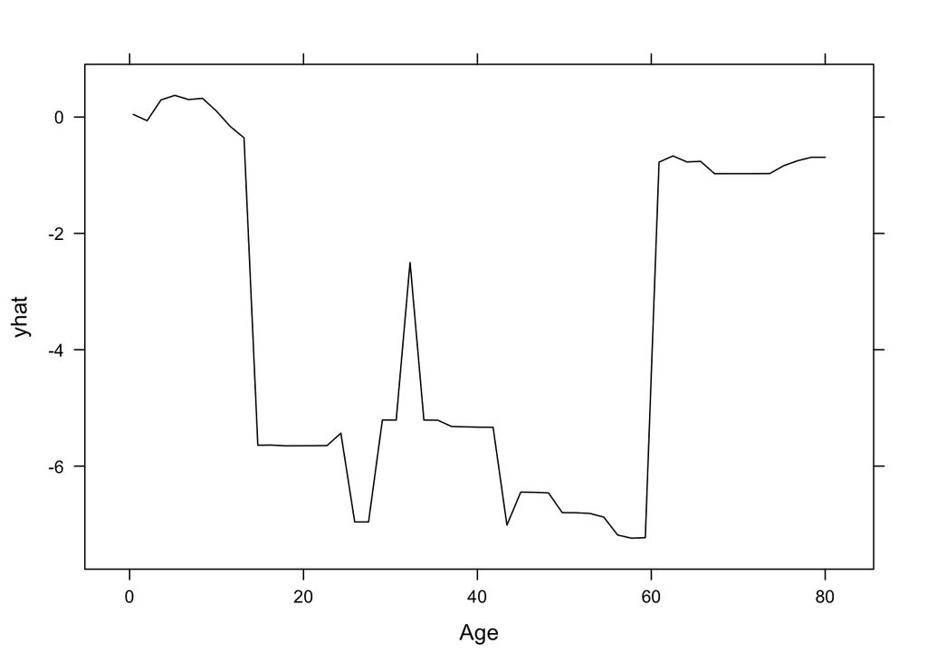

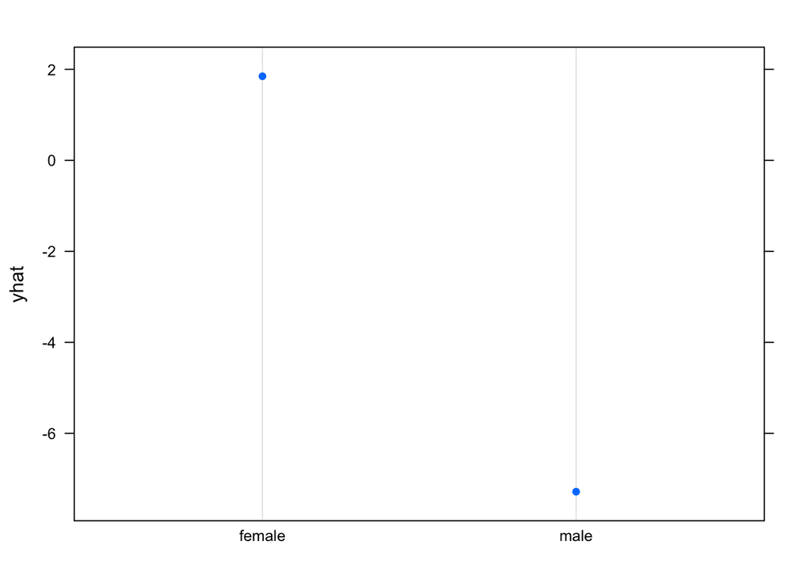

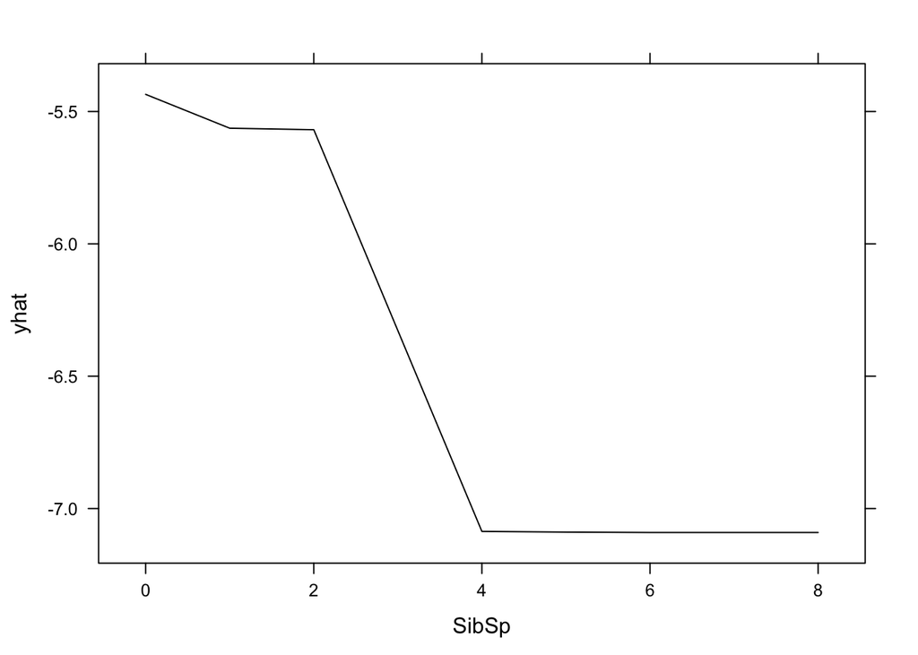